# Querying a CDM

Many of the OHDSI tools are designed to use a database in the OMOP common data model format. OHDSI Studies and tools will send SQL to the database

```r
library(DatabaseConnector)
connectionDetails <- createConnectionDetails(dbms = "redshift",
                                             user = "master",
                                             server = Sys.getenv("DB_SERVER"),
                                             password = Sys.getenv("DB_PASSWORD"),
                                             # password = keyring::key_get(), # use the keyring package to store and retreive passwords
                                             # password = rstudioapi::askForPassword(), # interactively prompt for password
                                             port = "5439")

conn <- connect(connectionDetails)
```

```
## Connecting using Redshift driver
```

```r
# disconnect(con) # use the disconnect function to disconnect
```

There are a few ways we can query the database from R.

**1) Using dbGetQuery() or similar R functions exported from the DatabaseConnector package**

```r
# send one query and get a result set
dbGetQuery(conn, "select * from synthea1k.concept limit 5")
```

```
##   concept_id            concept_name domain_id vocabulary_id
## 1          2                  Gender  Metadata        Domain
## 2          4               Ethnicity  Metadata        Domain
## 3          5 Observation period type  Metadata        Domain
## 4          7                Metadata  Metadata        Domain
## 5          9              Visit type  Metadata        Domain
##   concept_class_id standard_concept   concept_code valid_start_date
## 1           Domain             <NA> OMOP generated       1970-01-01
## 2           Domain             <NA> OMOP generated       1970-01-01
## 3           Domain             <NA> OMOP generated       1970-01-01
## 4           Domain             <NA> OMOP generated       1970-01-01
## 5           Domain             <NA> OMOP generated       1970-01-01
##   valid_end_date invalid_reason
## 1     2099-12-31           <NA>
## 2     2099-12-31           <NA>
## 3     2015-10-15              U
## 4     2099-12-31           <NA>
## 5     2015-10-15              U
```

```r
# send one query and get result set
querySql(conn, sql = "select * from synthea1k.concept limit 2;")
```

```
##   CONCEPT_ID        CONCEPT_NAME DOMAIN_ID VOCABULARY_ID CONCEPT_CLASS_ID
## 1          0 No matching concept  Metadata          None        Undefined
## 2          1              Domain  Metadata        Domain           Domain
##   STANDARD_CONCEPT        CONCEPT_CODE VALID_START_DATE VALID_END_DATE
## 1             <NA> No matching concept       1970-01-01     2099-12-31
## 2             <NA>      OMOP generated       1970-01-01     2099-12-31
##   INVALID_REASON
## 1           <NA>
## 2           <NA>
```

```r
# send multiple queries separated by semicolons
# note that executeSql does not return a result. It is used to create/modify tables in the database
executeSql(conn, "drop table if exists #x; create table #x (k INT); insert into #x values (2);")
```

```
##
## Executing SQL took 0.0533 secs
```

```r
querySql(conn, "select * from #x")
```

```
##   K
## 1 2
```

**2) Using a SQL code chunk in our notebook.** Run one sql query and get a result

```sql
select * from synthea1k.concept limit 5
```

5 records

| concept_id | concept_name | domain_id | vocabulary_id | concept_class_id | standard_concept | concept_code | valid_start_date | valid_end_date | invalid_reason |
| --- | --- | --- | --- | --- | --- | --- | --- | --- | --- |
| 2 | Gender | Metadata | Domain | Domain | NA | OMOP generated | 1970-01-01 | 2099-12-31 | NA |
| 4 | Ethnicity | Metadata | Domain | Domain | NA | OMOP generated | 1970-01-01 | 2099-12-31 | NA |
| 5 | Observation period type | Metadata | Domain | Domain | NA | OMOP generated | 1970-01-01 | 2015-10-15 | U |
| 7 | Metadata | Metadata | Domain | Domain | NA | OMOP generated | 1970-01-01 | 2099-12-31 | NA |
| 9 | Visit type | Metadata | Domain | Domain | NA | OMOP generated | 1970-01-01 | 2015-10-15 | U |

Save result set to an R dataframe.

```sql
select * from synthea1k.concept limit 5
```

```r
df
```

```
##   concept_id            concept_name domain_id vocabulary_id
## 1          2                  Gender  Metadata        Domain
## 2          4               Ethnicity  Metadata        Domain
## 3          5 Observation period type  Metadata        Domain
## 4          7                Metadata  Metadata        Domain
## 5          9              Visit type  Metadata        Domain
##   concept_class_id standard_concept   concept_code valid_start_date
## 1           Domain             <NA> OMOP generated       1970-01-01
## 2           Domain             <NA> OMOP generated       1970-01-01
## 3           Domain             <NA> OMOP generated       1970-01-01
## 4           Domain             <NA> OMOP generated       1970-01-01
## 5           Domain             <NA> OMOP generated       1970-01-01
##   valid_end_date invalid_reason
## 1     2099-12-31           <NA>
## 2     2099-12-31           <NA>
## 3     2015-10-15              U
## 4     2099-12-31           <NA>
## 5     2015-10-15              U
```

Note that if we make an error in our sql query we may need to send the rollback command to clear the transaction. This happens with postgres and redshift.

**3) Using dplyr (discussed later)**

# Get to know your schemas

1. cdmDatabaseSchema - the schema where your cdm lives (usually each cdm gets its own schema)
2. cohortDatabaseSchema - A schema where cohort tables can be created. You must have write access to this schema.
3. vocabDatabase - The schema where the vocabulary tables live (Usually same as the cdmDatabaseSchema)
4. resultsDatabaseSchema

We also need the name of the cdm database so each of these schemas is fully specified.

`databaseName.schemaName.tableName`

To find these schemas we can look in a few places. - The rstudio connections pane (upper right) - Querying the information_schema.tables table

```sql
select distinct table_schema from information_schema.tables
```

Displaying records 1 - 12

| table_schema |
| --- |
| information_schema |
| pg_catalog |
| pg_temp_10 |
| pg_temp_4 |
| synthea100k |
| synthea100kresults |
| synthea1k |
| synthea1kresults |
| synthea23m |
| synthea23mresults |

```r
cdmDatabaseSchema <- "mycdm.synthea1k"
cohortDatabaseSchema <- "mycdm.synthea1kresults"
vocabDatabaseSchema <- "mycdm.synthea1k"
resultsDatabaseSchema <- "mycdm.synthea1kresults"
```

Not all of these will be used for everything we do but we need to know what they are.

# Explore the CDM using SQL

We can get a long way toward understanding our data using SQL.

Some good places to look for example sql queries are

http://cdmqueries.omop.org/ https://data.ohdsi.org/QueryLibrary/

For example perhaps we want to know “what are the most prevalent concepts in the observation table?”

```sql
select concept_id, concept_name, count(*) as n
from synthea1k.observation a
inner join synthea1k.concept b
  on a.observation_concept_id = b.concept_id
group by concept_id, concept_name
order by n desc
limit 5;
```

5 records

| concept_id | concept_name | n |
| --- | --- | --- |
| 0 | No matching concept | 7074 |
| 4060985 | Body mass index 30+ - obesity | 501 |
| 4256640 | Body mass index 40+ - severely obese | 133 |
| 4304110 | Allergy to mold | 85 |
| 439406 | Allergy to animal dander | 84 |

# Rolling back a SQL transaction

When using postgres or redshift we might need to rollback a sql transaction if we have an error in our SQL code.

```r
# a query with a typo
dbGetQuery(conn, "select * from synthea1k.concpt limit 1")
```

```
## Error in rJava::.jnew("org.ohdsi.databaseConnector.BatchedQuery", connection@jConnection, : java.sql.SQLException: [Amazon](500310) Invalid operation: relation "synthea1k.concpt" does not exist;
```

```r
# subsequent queries might give an error like "commands ignored until end of transaction block"
dbGetQuery(conn, "select * from synthea1k.concept limit 1")
```

```
## Error in rJava::.jnew("org.ohdsi.databaseConnector.BatchedQuery", connection@jConnection, : java.sql.SQLException: [Amazon](500310) Invalid operation: current transaction is aborted, commands ignored until end of transaction block;
```

```r
# rollback resets the transaction
dbExecute(conn, "rollback;")
```

```
## [1] 0
```

```r
# the error is gone
dbGetQuery(conn, "select * from synthea1k.concept limit 1")
```

```
##   concept_id concept_name domain_id vocabulary_id concept_class_id
## 1          2       Gender  Metadata        Domain           Domain
##   standard_concept   concept_code valid_start_date valid_end_date
## 1             <NA> OMOP generated       1970-01-01     2099-12-31
##   invalid_reason
## 1           <NA>
```

# Example of using an OHDSI tool

In addition to running SQL queries we can use standardized analytic tools that query the database for us.

In this example we will run Achilles which is a powerful database characterization tool.

```r
# Make sure that cdm source has at least one row - this fix should be applied before the tutorial.
executeSql(conn, "insert into synthea1k.cdm_source (cdm_source_name) values ('synthea1k');")
executeSql(conn, "insert into synthea100k.cdm_source (cdm_source_name) values ('synthea100k');")
executeSql(conn, "insert into synthea23m.cdm_source (cdm_source_name) values ('synthea23mk');")
```

```r
# What is the reason for this error?***********************
# check that all the correct tables exist
Achilles::validateSchema(
  connectionDetails = connectionDetails,
  cdmDatabaseSchema = "mycdm.synthea1k",
  resultsDatabaseSchema = "mycdm.synthea1kresults",
  cdmVersion = "5.3",
  runCostAnalysis = F,
  outputFolder = "~/validationOutput")
```

```r
# create scratch schema and achilles schema
executeSql(conn, "create schema username_scratch; create schema username_synthea1k_results;")
```

```r
achillesResults <- Achilles::achilles(connectionDetails,
         cdmDatabaseSchema = "mycdm.synthea1k",
         resultsDatabaseSchema = "mycdm.username_synthea1k_results",
         scratchDatabaseSchema = "mycdm.username_scratch",
         vocabDatabaseSchema = "mycdm.synthea1k",
         numThreads = 1,
         sourceName = "Synthea1k",
         cdmVersion = "5.3",
         analysisIds = c(0:2, 5), # for demonstartion we will only execute a few analyses
         runHeel = F,
         # conceptHierarchy = F,
         runCostAnalysis = F)
```

```
## Connecting using Redshift driver
## Beginning single-threaded execution
## Connecting using Redshift driver
##
## Executing SQL took 0.185 secs
## Executing multiple queries. This could take a while
## Analysis 0 (Source name) -- START
##
## Executing SQL took 0.135 secs
## [Main Analysis] [COMPLETE] 0 (0.142230 secs)
## Analysis 1 (Number of persons) -- START
##
## Executing SQL took 0.0627 secs
## [Main Analysis] [COMPLETE] 1 (0.066867 secs)
## Analysis 2 (Number of persons by gender) -- START
##
## Executing SQL took 0.0693 secs
## [Main Analysis] [COMPLETE] 2 (0.073312 secs)
## Analysis 5 (Number of persons by ethnicity) -- START
##
## Executing SQL took 0.0756 secs
## [Main Analysis] [COMPLETE] 5 (0.079585 secs)
## Merging scratch Achilles tables
##
## Executing SQL took 0.184 secs
##
## Executing SQL took 0.156 secs
## Done. Achilles results can now be found in schema mycdm.username_synthea1k_results
```

Achilles results can be viewed in Atlas under the data sources section.

Another tool that is helpful to run to check that your CDM is ready for prime time is DataQualityDashboard. As a researcher or data scientist you are probably not the person who created the CDM you want to use. How can you gain confidence that the CDM conforms to the correct specification and that the standardized analytics will work correctly?

```r
# check that all cdm fields are present
dqChecks <- DataQualityDashboard::executeDqChecks(connectionDetails = connectionDetails,
                                                  cdmDatabaseSchema = "mycdm.synthea1k",
                                                  resultsDatabaseSchema = "mycdm.synthea1kresults",
                                                  writeToTable = F,
                                                  cdmSourceName = "Synthea1k",
                                                  outputFolder = "~/synthea1kDQChecks",
                                                  checkNames = "cdmField")
```

```
## Connecting using Redshift driver
## Connecting using Redshift driver
```

```r
# which fields are missing?
library(dplyr)
dqChecks %>%
  filter(FAILED == 1) %>%
  select(CDM_TABLE_NAME, CDM_FIELD_NAME)
```

```
##       CDM_TABLE_NAME                 CDM_FIELD_NAME
## 1.132   VISIT_DETAIL        visit_detail_start_date
## 1.133   VISIT_DETAIL    visit_detail_start_datetime
## 1.134   VISIT_DETAIL          visit_detail_end_date
## 1.135   VISIT_DETAIL      visit_detail_end_datetime
## 1.136   VISIT_DETAIL   visit_detail_type_concept_id
## 1.139   VISIT_DETAIL      visit_detail_source_value
## 1.140   VISIT_DETAIL visit_detail_source_concept_id
## 1.277           COST      revenue_code_source_value
```

We can also open the log that was created

```r
file.edit("~/synthea1kDQChecks/Synthea1k/log_DqDashboard_Synthea1k.txt")
```

or view the results in the DQ Dashboard.

```r
DataQualityDashboard::viewDqDashboard("~/synthea1kDQChecks/Synthea1k/results_Synthea1k.json")
```

It looks like we are missing a lot from the visit detail table. Let’s confirm this.

```r
df <- dbGetQuery(conn, "select * from synthea1k.VISIT_DETAIL limit 5")
nrow(df)
```

```
## [1] 0
```

```r
colnames(df)
```

```
##  [1] "visit_detail_id"             "person_id"
##  [3] "visit_detail_concept_id"     "visit_start_date"
##  [5] "visit_start_datetime"        "visit_end_date"
##  [7] "visit_end_datetime"          "visit_type_concept_id"
##  [9] "provider_id"                 "care_site_id"
## [11] "admitting_source_concept_id" "discharge_to_concept_id"
## [13] "preceding_visit_detail_id"   "visit_source_value"
## [15] "visit_source_concept_id"     "admitting_source_value"
## [17] "discharge_to_source_value"   "visit_detail_parent_id"
## [19] "visit_occurrence_id"
```

```r
df <- dbGetQuery(conn, "select * from synthea1k.COST limit 5")
nrow(df)
```

```
## [1] 0
```

```r
colnames(df)
```

```
##  [1] "cost_id"                  "cost_event_id"
##  [3] "cost_domain_id"           "cost_type_concept_id"
##  [5] "currency_concept_id"      "total_charge"
##  [7] "total_cost"               "total_paid"
##  [9] "paid_by_payer"            "paid_by_patient"
## [11] "paid_patient_copay"       "paid_patient_coinsurance"
## [13] "paid_patient_deductible"  "paid_by_primary"
## [15] "paid_ingredient_cost"     "paid_dispensing_fee"
## [17] "payer_plan_period_id"     "amount_allowed"
## [19] "revenue_code_concept_id"  "reveue_code_source_value"
## [21] "drg_concept_id"           "drg_source_value"
```

In the case of the cost table it looks like we have a typo in the name “reveue_code_source_value”. These types of checks can help avoid errors later on when using OHDSI tools.

Read about dataQualityDashboard options at https://ohdsi.github.io/DataQualityDashboard/articles/CheckTypeDescriptions.html

# Using dplyr for queries

dplyr is a popular data manipulation tool in R. We can also use dplyr to query the cdm but we will need to connect using the DBI::dbConnect function.

```r
library(dplyr)
library(RPostgreSQL)
host <- stringr::str_remove(Sys.getenv("DB_SERVER"), "/mycdm")

con <- DBI::dbConnect(drv = dbDriver("PostgreSQL"),
                      host = host,
                      dbname = "mycdm",
                      user = "master",
                      password = Sys.getenv("DB_PASSWORD"),
                      port = "5439")



condition <- tbl(con, dbplyr::in_schema("synthea1k", "condition_occurrence"))
concept <- tbl(con, dbplyr::in_schema("synthea1k", "concept"))

# What are the most frequently occuring condition concepts?
condition %>%
  inner_join(concept, by = c("condition_concept_id" = "concept_id")) %>%
  count(condition_concept_id, concept_name, sort = T)
```

```
## # Source:     lazy query [?? x 3]
## # Database:   postgres 8.0.2
## #   [master@ohdsi-databasesstack-fpcqgr4rskff-redshiftcluster-1sysoum9ioyw4.cn3hq8dfta6k.us-east-1.redshift.amazonaws.com:5439/mycdm]
## # Groups:     condition_concept_id
## # Ordered by: desc(n)
##    condition_concept_id concept_name                       n
##                   <int> <chr>                          <dbl>
##  1             40481087 Viral sinusitis                 1134
##  2                    0 No matching concept              825
##  3              4112343 Acute viral pharyngitis          636
##  4               260139 Acute bronchitis                 531
##  5              4217975 Normal pregnancy                 522
##  6              4311629 Impaired glucose tolerance       310
##  7               316866 Hypertensive disorder            299
##  8               257012 Chronic sinusitis                232
##  9              4078393 Miscarriage in first trimester   191
## 10               372328 Otitis media                     170
## # … with more rows
```

# Parameterized SQL & SQL translation

In OHDSI we frequently want to run SQL on multiple databases with only slight modifications. Rather than copying the SQL code we can use parameters to abstract away the differences. The SqlRender package provides the functionality to write parameterized SQL as well as translate SQL from the OHDSI SQL dialect (a subset of SQL Server’s T-SQL) to a variety of other database dialects automatically. (Postgres, Big Query, Impala, Oracle, ect.)

```r
library(SqlRender)

# We can paramaterize SQL
sql <- "SELECT * FROM @x WHERE person_id = @a;"
render(sql, x = "observation", a = 123)
```

```
## [1] "SELECT * FROM observation WHERE person_id = 123;"
```

```r
# And translate it to different database dialects
sql <- "SELECT TOP 10 * FROM person;"
translate(sql, targetDialect = "postgresql")
```

```
## [1] "SELECT  * FROM person LIMIT 10;"
```

Suppose we want to execute a query created by someone in the OHDSI community on our database. We can use SqlRender to accomplish this. Let’s finish up this section by executing a modified version of the query in The Book of OHDSI https://ohdsi.github.io/TheBookOfOhdsi/SqlAndR.html#implementing-the-study-using-sql-and-r

Instead of a drug exposure-condition outcome rate let’s look at the incidence of amputation among patients with type 2 diabetes.

```r
# create the parameters we will use for sql queries
cohortDatabaseSchema <- "mycdm.work_user1"
cohortTable <- "cohort"
cdmDatabaseSchema <- "mycdm.synthea23m"
```

```r
# create an empty cohort table
renderTranslateExecuteSql(conn,
                          "DROP TABLE IF EXISTS @cohort_db_schema.@cohort_table;",
                          cohort_db_schema = cohortDatabaseSchema,
                          cohort_table = cohortTable)
```

```
##
## Executing SQL took 0.0313 secs
```

```r
sql <- "
CREATE TABLE @cohort_db_schema.@cohort_table (
  cohort_definition_id INT,
  cohort_start_date DATE,
  cohort_end_date DATE,
  subject_id BIGINT
);
"
renderTranslateExecuteSql(conn, sql,
                          cohort_db_schema = cohortDatabaseSchema,
                          cohort_table = cohortTable)
```

```
##
## Executing SQL took 0.035 secs
```

The CohortDiagnostics package contains a convenience function for doing this as well.

```r
# This function will overwrite an existing cohort table of the same name!
CohortDiagnostics::createCohortTable(connection = conn,
                                     cohortDatabaseSchema = cohortDatabaseSchema,
                                     cohortTable = cohortTable)
```

**Create exposure cohort** Cohort entry will be first occurrence of type 2 diabetes mellitus and cohort exit will be the end of continuous observation.

```r
sql <- "
INSERT INTO @cohort_db_schema.@cohort_table (
  cohort_definition_id,
  cohort_start_date,
  cohort_end_date,
  subject_id
)
SELECT
  1 AS cohort_definition_id,
  cohort_start_date,
  observation_period_end_date as cohort_end_date,
  subject_id
FROM (
  SELECT
    condition_start_date AS cohort_start_date,
    person_id AS subject_id
  FROM (
    SELECT
      condition_start_date,
      condition_end_date,
      person_id,
      ROW_NUMBER() OVER (
        PARTITION BY person_id
            ORDER BY condition_start_date
      ) order_nr
    FROM @cdm_db_schema.condition_occurrence
    WHERE condition_concept_id =    201826 -- Type 2 Diabetes Mellitus
  ) ordered_exposures
  WHERE order_nr = 1
) first_occurrence
INNER JOIN @cdm_db_schema.observation_period
  ON subject_id = person_id
    AND observation_period_start_date < cohort_start_date
    AND observation_period_end_date > cohort_start_date
"




renderTranslateExecuteSql(conn, sql,
                          cohort_db_schema = cohortDatabaseSchema,
                          cohort_table = cohortTable,
                          cdm_db_schema = cdmDatabaseSchema)
```

```
##
## Executing SQL took 5.91 secs
```

**Create outcome cohort** Cohort entry will be on the day of a leg or foot amputation. Cohort exit will be the same day as the procedure.

```r
sql <- "
INSERT INTO @cohort_db_schema.@cohort_table (
 cohort_definition_id,
 cohort_start_date,
 cohort_end_date,
subject_id
)
SELECT
  2 AS cohort_definition_id,
  cohort_start_date,
  cohort_end_date,
  subject_id
FROM (
  SELECT DISTINCT
    person_id AS subject_id,
    procedure_date AS cohort_start_date,
    procedure_date AS cohort_end_date
  FROM @cdm_db_schema.procedure_occurrence
  WHERE procedure_concept_id IN(4195136, 4108565) -- Amputation of foot or above knee
) distinct_occurrence
"

renderTranslateExecuteSql(conn, sql,
                          cohort_db_schema = cohortDatabaseSchema,
                          cohort_table = cohortTable,
                          cdm_db_schema = cdmDatabaseSchema)
```

```
##
## Executing SQL took 6.88 secs
```

```sql
 SELECT DISTINCT
    person_id AS subject_id,
    procedure_date AS cohort_start_date,
    procedure_date AS cohort_end_date
  FROM mycdm.synthea100k.procedure_occurrence
  WHERE procedure_concept_id = 4195136 or procedure_concept_id =  4108565
```

Displaying records 1 - 27

| subject_id | cohort_start_date | cohort_end_date |
| --- | --- | --- |
| 12684 | 2014-08-25 | 2014-08-25 |
| 13133 | 2009-11-05 | 2009-11-05 |
| 13355 | 2002-04-17 | 2002-04-17 |
| 13776 | 2016-12-13 | 2016-12-13 |
| 19141 | 2009-07-28 | 2009-07-28 |
| 42229 | 2012-08-07 | 2012-08-07 |
| 57609 | 2006-03-05 | 2006-03-05 |
| 76068 | 2015-12-09 | 2015-12-09 |
| 99910 | 2014-08-20 | 2014-08-20 |
| 1855 | 2018-06-30 | 2018-06-30 |

```r
# check to see how many patients are in the cohort
# glue is a nice package for building queries too. Anything inside {braces} is evaluated as R code.
dbGetQuery(conn, glue::glue("
select
  cohort_definition_id,
  count(*) as count
from {cohortDatabaseSchema}.{cohortTable}
group by cohort_definition_id"))
```

```
##   cohort_definition_id  count
## 1                    2    806
## 2                    1 165147
```

**Calculate the incidence rate**

```r
sql <- "
WITH tar AS (
  SELECT concept_name AS gender,
    FLOOR((YEAR(cohort_start_date) -
          year_of_birth) / 10)*10 AS age,
    subject_id,
    cohort_start_date,
    CASE WHEN DATEADD(DAY, 3650, cohort_start_date) >
      observation_period_end_date
    THEN observation_period_end_date
    ELSE DATEADD(DAY, 3650, cohort_start_date)
    END AS cohort_end_date
  FROM @cohort_db_schema.@cohort_table
  INNER JOIN @cdm_db_schema.observation_period
    ON subject_id = observation_period.person_id
      AND observation_period_start_date < cohort_start_date
      AND observation_period_end_date > cohort_start_date
  INNER JOIN @cdm_db_schema.person
    ON subject_id = person.person_id
  INNER JOIN @cdm_db_schema.concept
    ON gender_concept_id = concept_id
  WHERE cohort_definition_id = 1 -- Exposure
)
SELECT days.gender,
    days.age,
    days,
    CASE WHEN events IS NULL THEN 0 ELSE events END AS events
FROM (
  SELECT gender,
    age,
    SUM(DATEDIFF(DAY, cohort_start_date,
      cohort_end_date)) AS days
  FROM tar
  GROUP BY gender,
    age
) days
LEFT JOIN (
  SELECT gender,
      age,
      COUNT(*) AS events
  FROM tar
  INNER JOIN @cohort_db_schema.@cohort_table amputation
    ON tar.subject_id = amputation.subject_id
      AND tar.cohort_start_date <= amputation.cohort_start_date
      AND tar.cohort_end_date >= amputation.cohort_start_date
  WHERE cohort_definition_id = 2 -- Outcome
  GROUP BY gender,
    age
) events
ON days.gender = events.gender
  AND days.age = events.age;
"

results <- renderTranslateQuerySql(conn, sql,
                                   cohort_db_schema = cohortDatabaseSchema,
                                   cohort_table = cohortTable,
                                   cdm_db_schema = cdmDatabaseSchema,
                                   snakeCaseToCamelCase = TRUE)
```

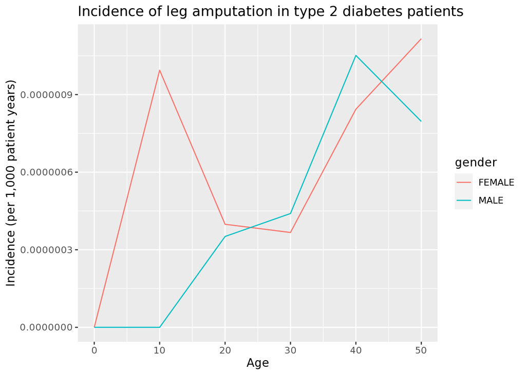

```r
# Compute incidence rate (IR) :
results$ir <- 1000 * results$events / results$days / 365

library(ggplot2)
ggplot(results, aes(x = age, y = ir, group = gender, color = gender)) +
  geom_line() +
  xlab("Age") +
  ylab("Incidence (per 1,000 patient years)") +
  ggtitle("Incidence of leg amputation in type 2 diabetes patients")
```

Notice how we used almost the same SQL code from the [The Book of OHDSI](https://ohdsi.github.io/TheBookOfOhdsi/SqlAndR.html#implementing-the-study-using-sql-and-r) but made some slight modifications by changing the concept IDs? This is ability to write generic SQL code that will run a type of analysis against any database in the OMOP CDM format is a foundational principle that many OHDSI tools are built on.

# Exercise

Head over to the [OHDSI Query Library](https://data.ohdsi.org/QueryLibrary/). Find a query that looks interesting and try to run it on the Synthea data. Use the data characterization reports in Atlas to identify what conditions/drugs/procedures are captured in your CDM. Share your query and results on in the Teams chat.

Always remember to disconnect from the database when you are done using it.

```r
DatabaseConnector::disconnect(conn)
DBI::dbDisconnect(con)
```

```
## [1] TRUE
```